# Project1

# 1 Loading and pre-processing the data

The following code will load the data into a data frame called “activities”. A working data frame called “tabs” will be created with a single entry for each date. The tapply function is used to calculate the sum and mean for each date and the values column bound to the tabs data frame. The data frame names are then adjusted to represent the column values.

```r
     activities<-read.csv("activity.csv")
     tabs<-as.data.frame(unique(activities$date))
     tabs<-cbind(tabs,tapply(activities$steps, activities$date, sum, na.rm=TRUE))
     tabs<-cbind(tabs,tapply(activities$steps, activities$date, mean, na.rm=TRUE))
     names(tabs)<-c("date", "sum", "mean")
```

# 2. Histogram of the total number of steps taken each day

The sum values calculated in the above section are used to generate the following histogram plot.

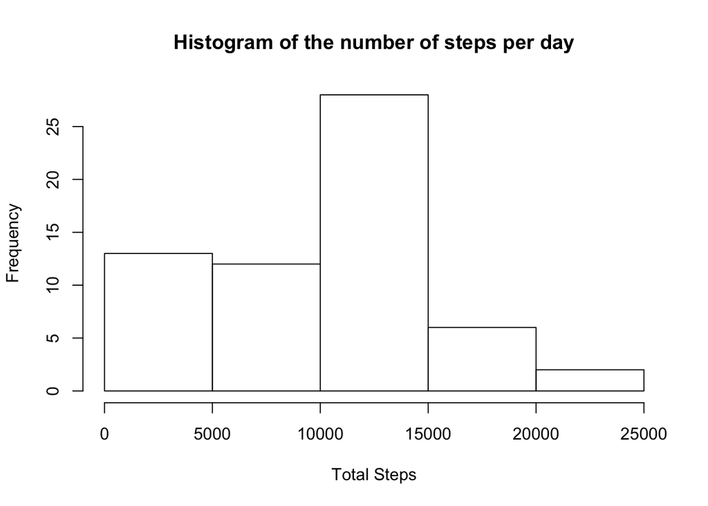

```r
     hist(tabs$sum, main="Histogram of the number of steps per day", xlab="Total Steps")
```

# 3. Mean and median number of steps taken each day

The Mean and Median are calculated with simple mean and median functions from the above totals.

```r
     meansteps<- as.integer(mean(tabs$sum, na.rm=TRUE))
     mediansteps<- median(tabs$sum, na.rm=TRUE)
```

The mean is calculated to be 9354 and the median is calculated to be 10395.

# 4. Time series plot of the average number of steps taken

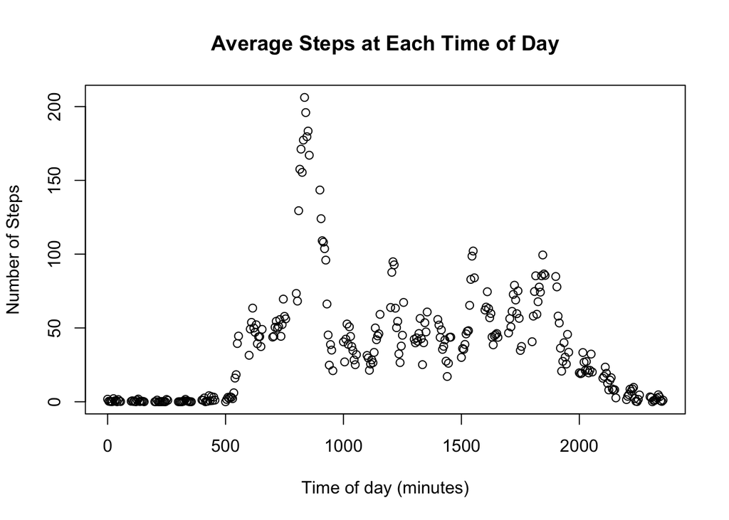

```r
     meantot<-tapply(activities$steps, activities$interval, mean, na.rm=TRUE)
     plot(names(meantot),meantot, ylab="Number of Steps", xlab="Time of day (minutes)",
          main="Average Steps at Each Time of Day")
```

# 5. The 5-minute interval that, on average, contains the maximum number of steps

```r
     sumtot<-tapply(activities$steps, activities$interval, sum, na.rm=TRUE)
     highstep<-names(which.max(sumtot))
```

Using the which function, the maximum number of steps was at the interval: 835.